# WQX Data Portal Exploration

Badhia Yunes Katz

January 2025

## Overview

On this markdown, data exploration will be done at a high level (and last 10 years only). The parameters of interest that were selected (for now) are: temperature, dissolved oxygen, turbidity and TSS.

The available databases on WQX are NWIS (USGS) and WQX(EPA). WQX is a data warehouse for water quality, biological, and physical data used by state environmental agencies, the EPA, other federal agencies, universities, private citizens, and others.

Note for pulling data: The WQP brings data from all these organizations together and provides it in a single format that has a more verbose output than NWIS. To get non-NWIS data, need to use CharacteristicName instead of parameter code.

```r
klamath_data <- whatWQPdata(huc = "180102")

summary <- klamath_data |>
  group_by(MonitoringLocationTypeName) |>   # Group by site type
  summarize(total_activities = sum(activityCount, na.rm = TRUE),
            total_results = sum(resultCount, na.rm = TRUE),
            site_count = n(),
            .groups = "drop")

print(summary)
```

```
## # A tibble: 39 × 4
##    MonitoringLocationTypeName         total_activities total_results site_count
##    <chr>                                         <dbl>         <dbl>      <int>
##  1 Atmosphere                                        0             0         44
##  2 Canal Transport                                 229          1878         19
##  3 Cave                                            104           664         14
##  4 Estuary                                        6047         17219         48
##  5 Facility Industrial                              57           489          3
##  6 Facility Municipal Sewage (POTW)                204          2461         11
##  7 Facility Other                                  109           599          7
##  8 Facility Public Water Supply (PWS)                0             0          7
##  9 Facility: Diversion                               0             0          1
## 10 Facility: Outfall                                 0             0          6
## # ℹ 29 more rows
```

### Temperature

Table showing the total temperature records for each organization for every year

[output not shown]

[output not shown]

```
##    OrganizationIdentifier year total_records
## 1               CALWR_WQX 2014             7
## 2       KLAMATHTRIBES_WQX 2014           695
## 3                NARS_WQX 2014            13
## 4               OREGONDEQ 2014            47
## 5                    QVIR 2014           166
## 6               RREPA_WQX 2014            12
## 7                 USGS-CA 2014            31
## 8                 USGS-OR 2014           345
## 9            1119USBR_WQX 2015             2
## 10           11NPSWRD_WQX 2015            24
## 11              CALWR_WQX 2015             7
## 12      KLAMATHTRIBES_WQX 2015           725
## 13              OREGONDEQ 2015            81
## 14                   QVIR 2015            35
```

[output cut: 78 more lines]

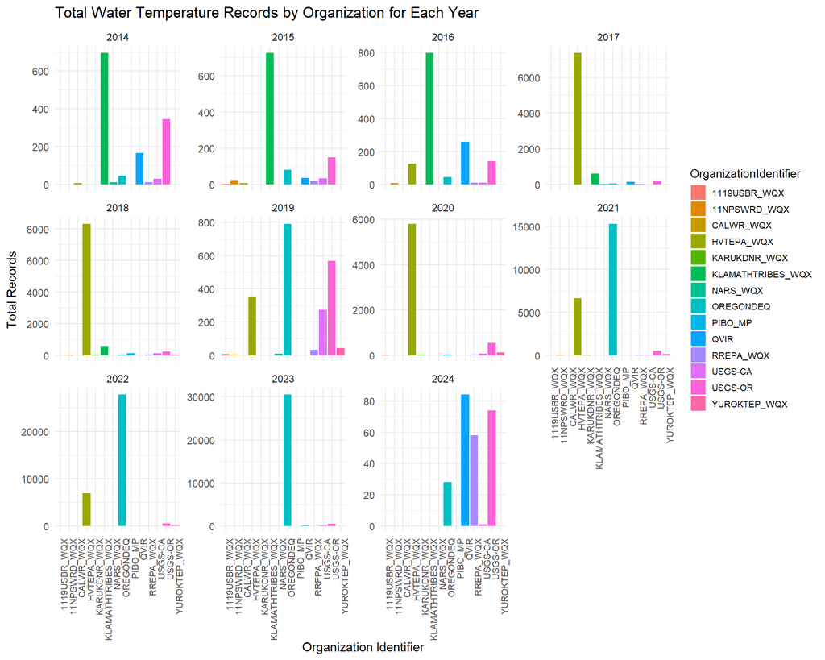

### Dissolved oxygen (DO)

Table showing the total DO records for each organization for every year

[output not shown]

[output not shown]

```
##    OrganizationIdentifier year total_records
## 1       KLAMATHTRIBES_WQX 2014           666
## 2                NARS_WQX 2014            13
## 3               OREGONDEQ 2014            47
## 4                    QVIR 2014           140
## 5            1119USBR_WQX 2015             2
## 6            11NPSWRD_WQX 2015            24
## 7                   CEDEN 2015             3
## 8       KLAMATHTRIBES_WQX 2015           725
## 9               OREGONDEQ 2015            81
## 10                   QVIR 2015            35
## 11              RREPA_WQX 2015            19
## 12           11NPSWRD_WQX 2016             8
## 13                  CEDEN 2016             3
## 14             HVTEPA_WQX 2016           126
```

[output cut: 56 more lines]

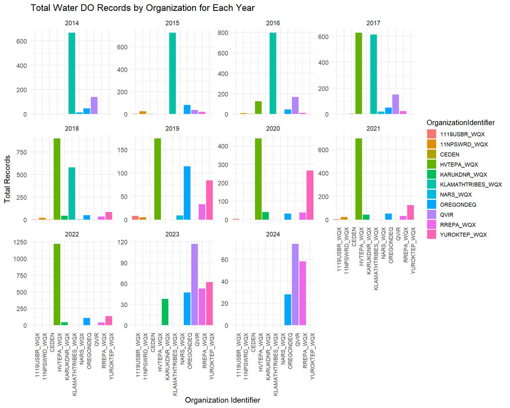

### Turbidity

Table showing the total turbidity records for each organization for every year

[output not shown]

[output not shown]

```
##    OrganizationIdentifier year total_records
## 1                   CEDEN 2014           189
## 2                NARS_WQX 2014             9
## 3               OREGONDEQ 2014            52
## 4                 USGS-CA 2014            29
## 5                 USGS-OR 2014           222
## 6            1119USBR_WQX 2015             2
## 7            11NPSWRD_WQX 2015            24
## 8                   CEDEN 2015           104
## 9               OREGONDEQ 2015            89
## 10              RREPA_WQX 2015            19
## 11                USGS-CA 2015             4
## 12                USGS-OR 2015            26
## 13           YUROKTEP_WQX 2015            85
## 14                  CEDEN 2016            98
```

[output cut: 58 more lines]

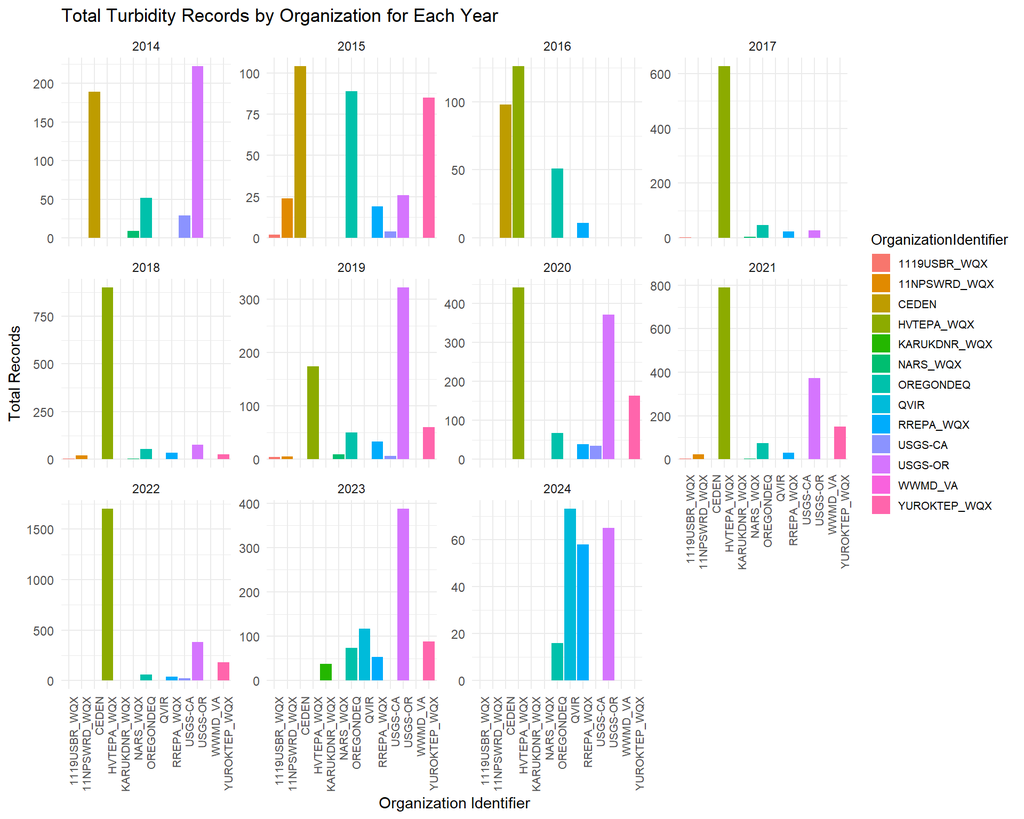

### Total suspended solids

Table showing the total Total suspended solids records for each organization for every year

[output not shown]

[output not shown]

```
##    OrganizationIdentifier year total_records
## 1                   CEDEN 2014           338
## 2                NARS_WQX 2014            13
## 3               OREGONDEQ 2014            47
## 4            1119USBR_WQX 2015             2
## 5                   CEDEN 2015           328
## 6       KLAMATHTRIBES_WQX 2015           111
## 7               OREGONDEQ 2015            81
## 8            YUROKTEP_WQX 2015            85
## 9                   CEDEN 2016           442
## 10      KLAMATHTRIBES_WQX 2016           195
## 11              OREGONDEQ 2016            45
## 12           1119USBR_WQX 2017             2
## 13                  CEDEN 2017             4
## 14              OREGONDEQ 2017            48
```

[output cut: 24 more lines]

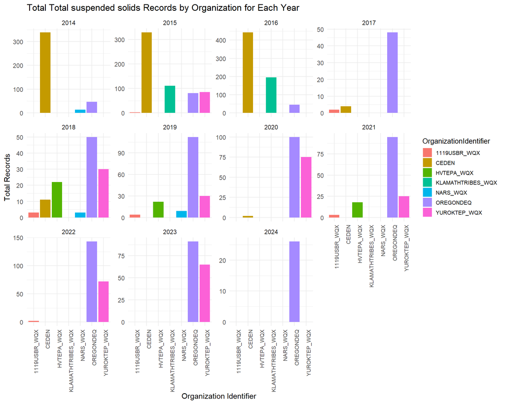

—- Maddee’s code below, keeping for reference for now —-

[interactive chart not shown]